# Lab 4 - Sampling distributions - KEY

Total: 90 pts

#### Load data:

```r
load(url("https://stat.duke.edu/~mc301/data/ames.RData"))
```

#### Set a seed:

```
2 pts for setting some seed
```

```r
set.seed(2102016)
```

## Exercises:

#### Exercise 1:

```
10 pts

- 2 pt for plot
- 2 pt for summary stats
- 6 pts for description:
  - 2 pt for using median & IQR instead of mean & sd
  - 2 pt for mentioning Q1 and Q3 as suggested in the instructions
  - 2 pt for stating min and max
```

The distribution of areas of houses in Ames is unimodal and right-skewed, with a median of 1,442 square feet. The middle 50% of the houses range between 1,126 square feet and 1,743 square feet, yielding an IQR of 617 square feet. The smallest house is 334 square feet and the largest is 5,642 square feet.

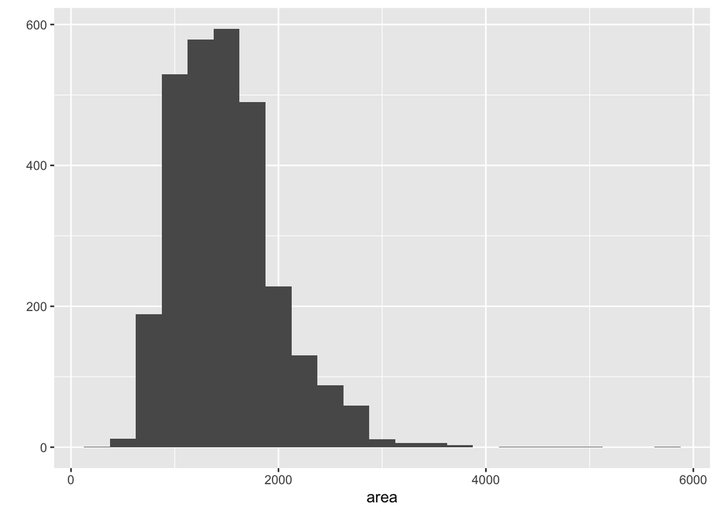

```r
qplot(data = ames, x = area, binwidth = 250)
```

```r
ames %>%
  summarise(mu = mean(area), pop_med = median(area),
            sigma = sd(area), pop_iqr = IQR(area),
            pop_min = min(area), pop_max = max(area),
            pop_q1 = quantile(area, 0.25),
            pop_q3 = quantile(area, 0.75))
```

```
## # A tibble: 1 x 8
##      mu pop_med sigma pop_iqr pop_min pop_max pop_q1 pop_q3
##   <dbl>   <dbl> <dbl>   <dbl>   <int>   <int>  <dbl>  <dbl>
## 1 1500.    1442  506.    617.     334    5642   1126  1743.
```

#### Exercise 2:

```
18 points

Note: Answers may vary since randomly sampling.

- 2 pt for sampling code
- 2 pts for plot
- 6 pts for summary stats: 3 pt for basic code, 3 pt for not using parameter as
labels (like x_bar instead of mu)
- 6 pts for description: 2 pt for using median & IQR instead of mean & sd, 2 pt for mentioning Q1 and Q3 as suggested in the instructions, 2 pt for stating min and max
- 2 pt for reasonable comparison to population distribution
```

The population and sample distribution are similar in shape but the sample d distribution appears to be slightly less skewed.

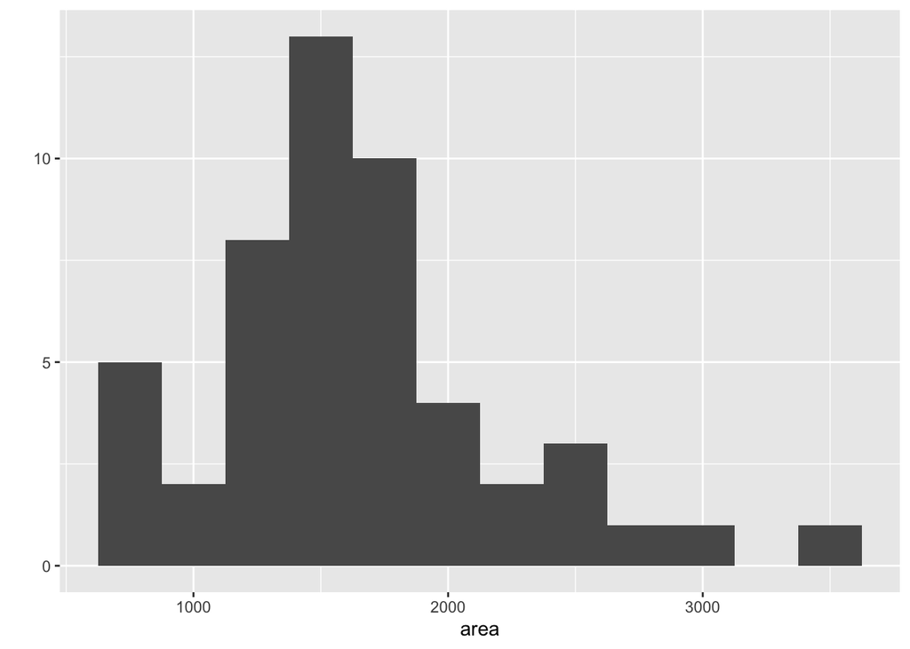

```r
samp1 <- ames %>%
  sample_n(50)
qplot(data = samp1, x = area, binwidth = 250)
```

```r
samp1 %>%
  summarise(xbar = mean(area), samp_med = median(area),
            s = sd(area), samp_iqr = IQR(area),
            samp_min = min(area), samp_max = max(area),
            samp_q1 = quantile(area, 0.25),
            samp_q3 = quantile(area, 0.75))
```

```
## # A tibble: 1 x 8
##    xbar samp_med     s samp_iqr samp_min samp_max samp_q1 samp_q3
##   <dbl>    <dbl> <dbl>    <dbl>    <int>    <int>   <dbl>   <dbl>
## 1 1630.    1548.  553.     537.      788     3608    1298   1835.
```

#### Exercise 3:

```
4 pts

- 2 pt: not same
- 2 pt: somewhat different
```

We would not expect the means of the two samples to be exactly the same (unless the same seed was used for sampling), but we would expect them to just be somewhat different and not very different.

#### Exercise 4:

```
6 pts

Note: First part of the answers may vary since randomly sampling.

- 2 pt for code/output for sampling and calculating mean of `samp2`
- 2 pt for comparing two samples with n = 50
- 2 pt for choosing between n = 1000 and n = 100
```

We would expect a sample with 1000 observations to yield a sample mean that would be a more accurate estimate of the population mean than a sample with 100 observations.

```r
samp2 <- ames %>%
  sample_n(50)

samp2%>%
  summarise(x_bar = mean(area))
```

```
## # A tibble: 1 x 1
##   x_bar
##   <dbl>
## 1 1398.
```

#### Exercise 5:

```
6 pts

- 2 pt for code / output
- 2 pt for 2,000 elements
- 2 pt for distribution description
```

There are 2,000 elements in `sample_means50`. The distribution of this sample is unimodal and symmetric, with mean 1,499 square feet and standard deviation 68.88 square feet.

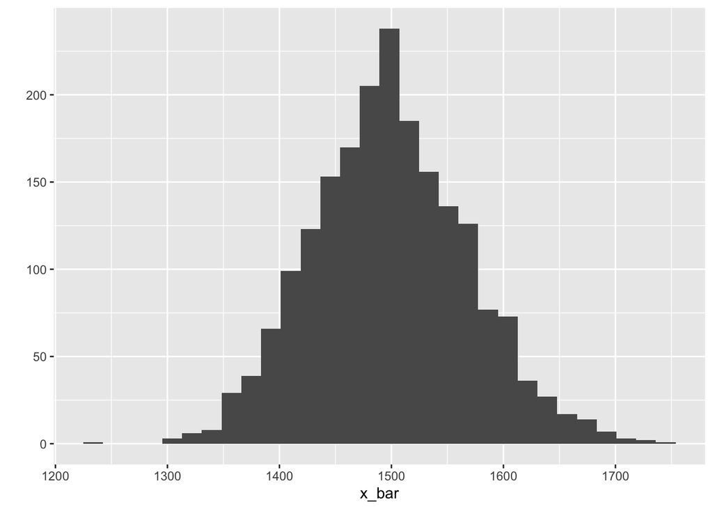

```r
sample_means50 <- do(2000) * ames %>%
                              sample_n(50, replace = TRUE) %>%
                              summarise(x_bar = mean(area))

qplot(data = sample_means50, x = x_bar)
```

#### Exercise 6:

```
6 pts

- 2 pt for code / output
- 2 pt for 25 observations
- 2 pt for each observation is a sample mean
```

The object `sample_means_small` contains 25 elements, and each observation represents a mean from a simple random sample.

```r
sample_means_small <- do(25) * ames %>%
                                sample_n(10, replace = TRUE) %>%
                                summarise(x_bar = mean(area))
sample_means_small
```

```
##     x_bar
## 1  1514.8
## 2  1528.0
## 3  1373.7
## 4  1238.3
## 5  1438.4
## 6  1601.5
## 7  1566.7
## 8  1285.0
## 9  1451.5
## 10 1493.8
## 11 1720.2
## 12 1430.9
## 13 1499.8
## 14 1245.9
## 15 1448.6
## 16 1316.0
## 17 1426.2
## 18 1554.2
## 19 1483.5
## 20 1431.2
## 21 1409.9
## 22 1553.9
## 23 1447.7
## 24 1332.4
## 25 1540.3
```

#### Exercise 7:

```
10 pts

- 2 pts for observations are sample means
- 2 pts for shape
- 2 pts for center
- 2 pts for spread
- 2 pts for nothing changes when number of simulations is increased
```

Each observation in the sampling distribution represents a sample mean.

As the sample size increases, the shape of the distribution becomes more symmetric (approaches normal), the standard error decreases, but the mean stays roughly the same.

Increasing the number of simulations does not affect the distribution.

## More Practice:

#### 8.

```
4 pts

Note: Answers may vary since randomly sampling.

- 2 pt for code
- 2 pt for estimation
```

```r
samp1 <- ames %>%
  sample_n(15)

samp1%>%
  summarise(x_bar = mean(price))
```

```
## # A tibble: 1 x 1
##    x_bar
##    <dbl>
## 1 154465
```

#### 9

```
10 pts

Note: First part of the answers may vary due to random sampling.

- 3 pt for sampling code
- 2 pt for plot code/output
- 2 pt for estimation
- 2 pt for confming with population mean
```

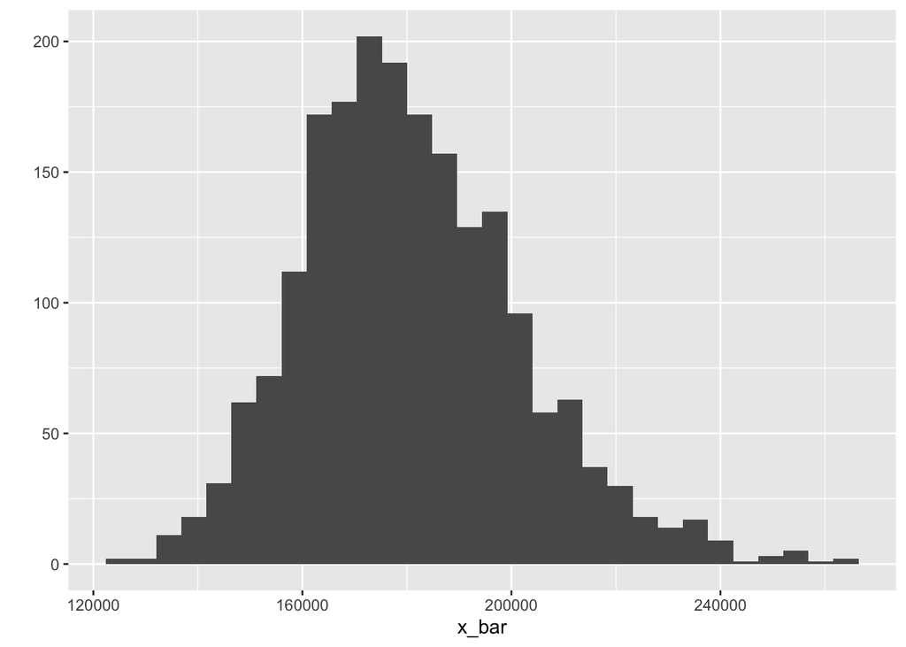

```r
sample_means15 <- do(2000) * ames %>%
                              sample_n(15, replace = TRUE) %>%
                              summarise(x_bar = mean(price))

qplot(data = sample_means15 , x = x_bar)
```

```r
sample_means15 %>%
  summarise(mean = mean(x_bar), sd = sd(x_bar))
```

```
##       mean       sd
## 1 180858.1 21046.35
```

```r
ames %>%
  summarise(pop_mean = mean(price))
```

```
## # A tibble: 1 x 1
##   pop_mean
##      <dbl>
## 1  180796.
```

#### 10

```
10 pts

Note: First part of the answers may vary due to random sampling.

- 3 pt for sampling code
- 2 pt for plot code/output
- 2 pt for estimation
- 2 pt for comparisons
```

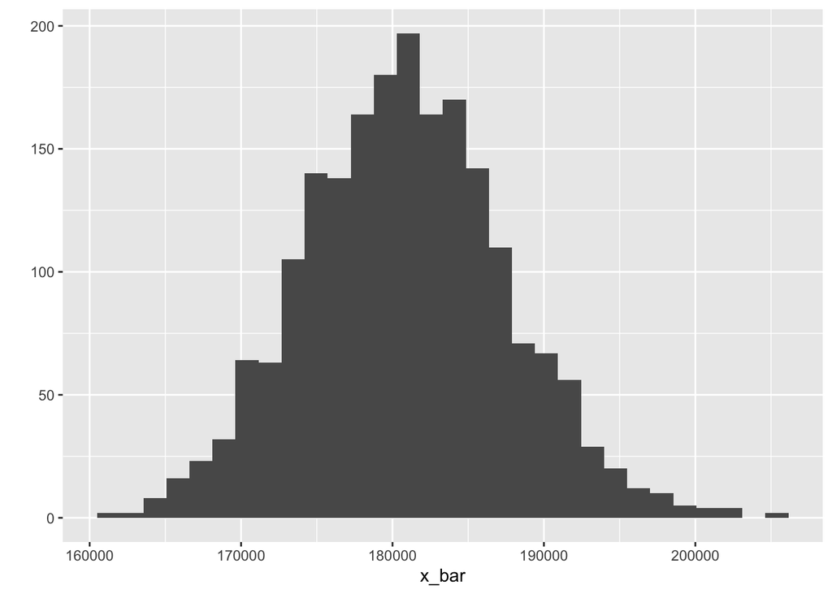

```r
sample_means150 <- do(2000) * ames %>%
                                sample_n(150, replace = TRUE) %>%
                                summarise(x_bar = mean(price))

qplot(data = sample_means150, x = x_bar)
```

```r
sample_means150 %>%
  summarise(mean = mean(x_bar), sd = sd(x_bar))
```

```
##     mean       sd
## 1 180872 6685.646
```

#### 11

```
4 pts

- 2 pt for which has smaller spread
- 2 pt for which to prefer
```

The standard error (measured as the standard deviation of the sampling distribution) for the second distribution is smaller than the first, which makes sense since the sample size is higher for the second sample. If we’re concerned with making estimates that are more often close to the true value, would we prefer a distribution with a small spread.